# Estudo baseado em uma lista de itens perdidos da bagagem no aeroporto em 2014

Daniel Castro de Farias

21/06/2021

# Introdução:

# Pacotes Requeridos:

```r
library(rmdformats) #Design do documento
library(ggplot2) #Plotar gráficos
library(dplyr) #Manipulação de tabelas
library(DT) #Interatividade
library(knitr) #Gerar tabelas
library(tidyr) #Manipulação de tabelas
library(readxl) #Ler arquivos xls
```

# Preparação dos dados:

## Origem dos dados

https://www.dhs.gov/sites/default/files/publications/claims-2014.xls

https://www.reddit.com/r/datasets/comments/5pn2re/tsa_claims_data_a_list_of_everything_lost_in/

## Informações sobre os dados

Os dados foram fornecidos através da plataforma do Reddit, são dados coletados no ano de 2014 com finalidade de estabelecer a transparência dos itens perdidos da bagagem em aeroportos e suas categorias de custo. Os dados originais (antes de ser tratados) possuem 8856 linhas e 11 colunas em um formato inicial “.xls”, os valores ausentes estavam representados pelo caractere “-“.

## Importação e limpeza dos dados

**Inicialmente os dados estavam no formato de planilha Excel “.xls”, para importar os arquivos foram utilizados os seguintes comandos:**

```r
#Lendo dados de uma planilha excel.
library(readxl)
perdidos_2014 <- read_excel("claims_2014.xlsx",
    col_types = c("double", "date", "date",
        "text", "text", "text", "text", "text",
        "text", "float", "text"))
```

Foi levado em consideração a conversão para os seus devidos formatos de acordo com as colunas, como por exemplo o formato “date”, nas colunas de data do incidente e data do recebimento em formato de data, bem como a conversão do preço estimado de determinado produto para valor decimal, adicionando automaticamente “NA” nos respectivos espaços em branco.

**Em seguida o projeto foi salvo em um arquivo “.csv” para facilitar a manipulação através do R.**

```r
write.csv(perdidos_2014, file = "projeto.csv", row.names = F)
```

**Importando o arquivo “.csv”**

```r
projeto <- read_csv(file = "projeto.csv")
```

**Checando se há arquivos duplicados:**

```r
which(duplicated(projeto))
```

Apesar de não haver arquivos duplicados, algumas linhas não contêm significância para análise geral dos dados, pois não apresentam o nome do aeroporto, companhia, ou custo relacionados à bagagem esquecida.

**Removendo linhas sem significância:**

```r
index<-which(projeto$`Airport Name`=="-")
projeto <- projeto[-index,]
```

**Padronizando categorias não relatadas para “Other”**

```r
projeto[which(projeto$`Claim Type` == "-"),7]<- "Other"
projeto[which(projeto$`Claim Site` == "-"),8]<- "Other"
projeto[which(projeto$`Item Category` == "-"),9]<- "Other"
```

**Padronizando as companhias não relatadas para “Not Identified”**

```r
projeto[which(projeto$`Airline Name` == "-"),6]<- "Not Identified"
```

**Reestruturando a variável data, para efetuar o cálculo de dias que a mercadoria ficou retida e em seguida criando uma nova coluna armazenando o número de dias de retenção**

```r
projeto$`Incident Date`<- as.Date(projeto$`Incident Date`, "%d:%m:%Y")
projeto <- cbind(projeto, days = (projeto$`Date Received`)-(projeto$`Incident Date`), stringsAsFactors = FALSE)
```

## Visualização dos dados

**Após realizar algumas manipulações nos dados iniciais, temos os seguintes dados:**

### Dados gerais

```r
#Setando dados mais relevantes para a apresentação na tabela.
main <- projeto %>% select(`Airport Name`, `Airline Name`, `Incident Date`, `Date Received`, `Claim Type`,
         `Item Category`, days)

main[1:150,] %>% DT::datatable()
```

|  | Airport Name | Airline Name | Incident Date | Date Received | Claim Type | Item Category | days |
| --- | --- | --- | --- | --- | --- | --- | --- |
| 1 | Westchester County, White Plains | USAir | 2012-12-21 | 2014-01-13 | Personal Injury | Audio/Video; Jewelry &amp; Watches | 388 |
| 2 | Orlando International Airport | Delta Air Lines | 2014-06-30 | 2014-07-17 | Property Damage | Other | 17 |
| 3 | Luis Munoz Marin International | Jet Blue | 2013-12-27 | 2014-01-07 | Property Damage | Food &amp; Drink | 11 |
| 4 | Washington Dulles International | UAL | 2014-01-02 | 2014-01-07 | Property Damage | Baggage/Cases/Purses | 5 |
| 5 | San Antonio International | Southwest Airlines | 2014-01-07 | 2014-01-09 | Property Damage | Computer &amp; Accessories | 2 |
| 6 | Charleston International | Delta Air Lines | 2013-12-15 | 2014-01-13 | Property Damage | Baggage/Cases/Purses | 29 |
| 7 | Luis Munoz Marin International | AirTran Airlines | 2013-03-24 | 2014-01-14 | Passenger Property Loss | Clothing; Cosmetics &amp; Grooming; Jewelry &amp; Watches | 296 |
| 8 | Los Angeles International Airport | Air Canada | 2013-12-23 | 2014-01-14 | Property Damage | Computer &amp; Accessories | 22 |
| 9 | TF Green Airport, Providence | USAir | 2013-12-29 | 2014-01-23 | Property Damage | Audio/Video | 25 |
| 10 | Bellingham International | Alaska Airlines | 2014-01-01 | 2014-01-27 | Property Damage | Jewelry &amp; Watches | 26 |

[output cut: 140 more lines]

### Dados dos itens com maior custo

```r
#Organizando os dados de acordo com os custos mais altos e exibindo na tabela.
cust<-arrange(cust, desc(`Close Amount`))

cust <- cust %>% select(`Airport Name`, `Airline Name`,`Claim Type`,
         `Item Category`,days, `Close Amount`)

cust[1:100,] %>% DT::datatable()
```

|  | Airport Name | Airline Name | Claim Type | Item Category | days | Close Amount |
| --- | --- | --- | --- | --- | --- | --- |
| 1 | Ft. Wayne Municipal- Baer Field | Not Identified | Property Damage | Other | 208 | 25483.44 |
| 2 | Non TSA Airport (motor vehicle) | Not Identified | Personal Injury | Other | 265 | 20000 |
| 3 | Sacramento International Airport | Not Identified | Property Damage | Other | 147 | 6183.36 |
| 4 | Non TSA Airport (motor vehicle) | Not Identified | Motor Vehicle | Other | 732 | 5158.05 |
| 5 | Newark International Airport | UAL | Property Damage | Sporting Equipment &amp; Supplies | 35 | 2500 |
| 6 | Chicago O'Hare International Airport | Spirit Airlines | Property Damage | Computer &amp; Accessories | 13 | 2430.74 |
| 7 | Hartsfield-Jackson Atlanta International Airport | Delta Air Lines | Passenger Property Loss | Medical/Science | 116 | 2400 |
| 8 | Minneapolis/ St.Paul International Airport | Not Identified | Property Damage | Other | 1 | 2300 |
| 9 | Orlando International Airport | Jet Blue | Passenger Property Loss | Other | 55 | 2250 |
| 10 | Atlantic City International | Not Identified | Motor Vehicle | Baggage/Cases/Purses | 361 | 2233.86 |

[output cut: 90 more lines]

### Dados dos Itens com maior tempo de retenção

```r
#Organizando os dados de acordo com os maiores números de dias retidos da bagagem.
timer<-arrange(projeto, desc(days))

timer <- timer %>% select(`Airport Name`,
         `Item Category`, `Incident Date`,`Date Received`,days)

timer[1:100,] %>% DT::datatable()
```

|  | Airport Name | Item Category | Incident Date | Date Received | days |
| --- | --- | --- | --- | --- | --- |
| 1 | Orlando International Airport | Other | 2011-08-24 | 2014-06-12 | 1023 |
| 2 | John F. Kennedy International | Currency | 2012-04-26 | 2014-12-04 | 952 |
| 3 | Miami International Airport | Clothing; Computer &amp; Accessories; Cosmetics &amp; Grooming | 2012-05-11 | 2014-11-19 | 922 |
| 4 | Ft. Lauderdale-Hollywood International | Other | 2011-11-28 | 2014-02-11 | 806 |
| 5 | Reno/Tahoe International | Other | 2012-09-26 | 2014-11-03 | 768 |
| 6 | Orlando International Airport | Other | 2011-12-27 | 2014-01-27 | 762 |
| 7 | Seattle-Tacoma International | Jewelry &amp; Watches; Medical/Science | 2012-11-01 | 2014-11-22 | 751 |
| 8 | Norman Y Mineta San Jose International | Jewelry &amp; Watches | 2012-04-21 | 2014-05-05 | 744 |
| 9 | Portland International | Other | 2012-02-18 | 2014-02-27 | 740 |
| 10 | Billings, MT | Home Decor; Personal Accessories | 2012-12-02 | 2014-12-08 | 736 |

[output cut: 90 more lines]

### Dados de aeroportos com maior incidência

```r
#Organizando os dados de acordo com os aeroportos que possuem as maiores frequências de perda de bagagem.
z<- projeto %>% count(`Airport Name`)
qtd<-arrange(z, desc(n))

qtd[1:50,] %>% DT::datatable()
```

|  | Airport Name | n |
| --- | --- | --- |
| 1 | John F. Kennedy International | 644 |
| 2 | Los Angeles International Airport | 454 |
| 3 | Orlando International Airport | 356 |
| 4 | Newark International Airport | 341 |
| 5 | Miami International Airport | 340 |
| 6 | Hartsfield-Jackson Atlanta International Airport | 302 |
| 7 | Chicago O'Hare International Airport | 248 |
| 8 | Boston (Logan) International Airport | 241 |
| 9 | McCarran International | 215 |
| 10 | Phoenix Sky Harbor International | 214 |

[output cut: 40 more lines]

## Resumo

**Detalhamento das variáveis e funcionalidades:**

**Claim Number:** Número de identificação registrado pelo TSA, funcionando de forma semelhante a um ID.

**Date Received:** Data no qual o produto perdido foi devolvido.

**Incident Date:** Data no qual ocorreu o incidente de perda.

**Airport Code**: Sigla do determinado aeroporto correspondente à bagagem perdida.

**Airport Name:** Nome do aeroporto.

**Airline Name:** Nome da companhia.

**Claim type:** Corresponde ao tipo de reclamação.

**Claim Site:** Corresponde ao site da reclamação.

**Item Category:** Corresponde à categoria do item.

**Close Amount:** Corresponde ao preço estimado da bagagem perdida.

**Disposition:** Corresponde ao status da bagagem.

**days:** Dias de retenção de determinada bagagem.

# Análise exploratória dos dados:

## As categorias dos itens mais perdidos

Podemos observar que diversos itens de amplas categorias são perdidos da bagagem, devido a esse fato podemos analisar qual categoria de item perdido obtém a maior frequência e com isso questionar o real motivo do acontecimento e tentar elaborar algumas soluções.

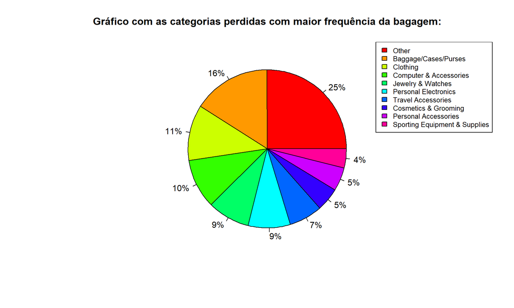

```r
#Classificando as categorias de itens mais perdidos.
categ<- projeto %>% count(`Item Category`)
categ<-arrange(categ, desc(n))

labels <- categ$`Item Category`[1:10]
x <- categ$n[1:10]

#Definindo cálculo de porcentagem.
pct <- round(x/sum(x)*100)
lbls<- paste(pct, "%", sep = "")

#Plotando gráfico do tipo Pizza.
pie(x, labels=lbls, main = "Gráfico com as categorias perdidas com maior frequência da bagagem:", col = rainbow(10), size=10)
legend("toprigh", legend = labels, cex = 0.8, fill = rainbow(10))
```

As categorias não identificadas ou que não se enquadravam em alguma outra categoria foram tratadas como “Other”, apesar de estar em maior parte do gráfico ela representa um conjunto de outras categorias.

Para uma análise mais profunda e real podemos observar que a categoria de itens perdidos com maior frequência costuma ser de itens carregados à mão, bem como bolsas, estojos e bagagem de mão de pequeno porte, seguidos dos itens de vestuário que por serem de fácil dispersão acabam sendo esquecidos com mais frequência.

Analisando esses dados deve-se emitir alertas de mais atenção e cuidado em relação a esses itens de fácil dispersão, buscando diminuir o índice geral de bagagens perdidas.

## Período com maior frequência de perdas

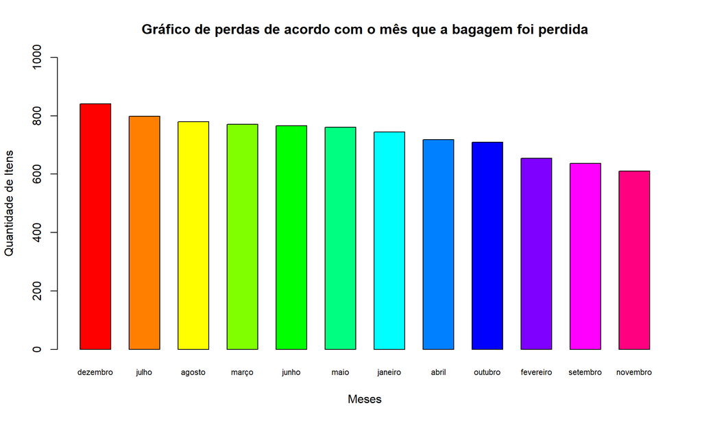

```r
#Selecionando os meses com maior quantidade de incidentes.
meses <- projeto %>% count(months.Date(projeto$`Incident Date`))
meses <- arrange(meses, desc(n))

labels <- meses[1:12,1]
x <- meses$n

#Plotando o gráfico do tipo barra.
barplot(x, names.arg = labels, cex.names = 0.7, space = 0.6, beside = T, ylim = c(0, 1000), col = rainbow(12), main = "Gráfico de perdas de acordo com o mês que a bagagem foi perdida", xlab="Meses", ylab="Quantidade de Itens")
```

## Tipos de reclamação de maior frequência

As reclamações de maior frequência dos passageiros que perdem sua bagagem são:

1 – Perda de propriedade do passageiro, ou seja, o item foi perdido e o valor será ressarcido de acordo com o custo estimado do item.

2 – Danos materiais, ou seja, houve avarias na bagagem, havendo possibilidades de reparação do item ou valor parcial ou total ressarcido ao cliente.

3 – Ferimento pessoal, ou seja, itens com valores pessoais e sentimentais foram avariados ou “mal cuidados”, de modo que gera um dano sem possibilidades de avaliação de custo para ressarcir.

4 – Outros motivos

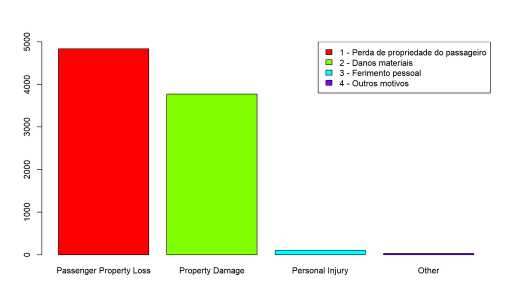

```r
#Filtrando os tipos de reclamação e as que possuem maior incidência
reclamacoes <- projeto %>% count(`Claim Type`)
reclamacoes<-arrange(reclamacoes, desc(n))
x<-reclamacoes$n
labels <- reclamacoes$`Claim Type`
reclamacoes$n[4]<-sum(reclamacoes$n[4:8])
labels2 <- c("1 - Perda de propriedade do passageiro", "2 - Danos materiais", "3 - Ferimento pessoal", "4 - Outros motivos")

#Plotando gráfico tipo barra e adicionando legenda.
barplot(x[1:4], ylim = c(0,5000), beside = T, names.arg = labels[1:4], col = rainbow(4))
legend("toprigh", legend = labels2, cex = 1, fill = rainbow(4))
```

## Sites com maior número de reclamação

[figure not shown]

```r
#Lista de sites com maior número de reclamação
sites <- projeto %>% count(`Claim Site`)
sites<-arrange(sites, desc(n))
x<-reclamacoes$n
labels = sites$`Claim Site`
sites$n[3]<-sum(sites$n[3:5])

#Plotando gráfico pizza com legenda.
pie(x[1:3], labels=lbls, main = "Gráfico com os sites de maior reclamação", col = c("red", "green", "blue"))
legend("toprigh", legend = labels[1:3], cex = 0.8, fill = c("red", "green", "blue"))
```

# Conclusão:

Por conseguinte, observa-se que com a exploração do dataset relacionado à perda de bagagens no ano de 2014 a partir de uma análise exploratória podemos obter um volume de dados interessante e extrair informações relevantes para possível manutenção de melhoria do serviço de recuperação e para emitir alertas aos passageiros em pontos cruciais.

A limitação da variação de dados acabou encurtando a análise de modo que não foi possível gerar uma amplitude extensa dessa exploração e replicação dos dados, ademais, o dataset escolhido é um pouco antigo tendo em vista que esse ambiente possui mudanças de serviços constantemente, principalmente com automação dos serviços, porém ainda sim é possível extrair muitas informações relevantes tanto para o passageiro quanto para os fornecedores do serviço.

Por fim, essa mesma análise de dados pode ser feita com dados mais recente e ser constantemente atualizada, ocasionando melhorias do serviço, impulsionando a parte financeira desse setor e trazendo melhorias para seus usuários.